# RTIGER reimplementation benchmark: nilHMM C++/Rcpp vs Julia

- Show All Code
- Hide All Code
- View Source

Supplement (optimization): correctness-first equivalence, then throughput/memory at the operating rigidity r=250

Author

Fausto Rodríguez-Zapata

Published

July 20, 2026

**TipMeasured on real Arabidopsis data, at the operating rigidity r=250**

Numbers, tables and figures below are the live benchmark at this dataset’s operating rigidity **r = 250** (`scripts/bench_rtiger_r250.R` for the C++ core, `scripts/rtiger_julia_conv_worker.jl` for the original), not placeholders. The both cores are measured at all five panel sizes (the original’s full 110k fit takes ~43 min, vs ~0.2 s for the C++/Rcpp core).

**Thesis.** nilHMM reimplements the RTIGER rigid-HMM core in **C++/Rcpp** (`nilhmm/src/rtiger.cpp`), removing the Julia backend that upstream RTIGER [Campos-Martin 2023] requires through `JuliaCall`. The reimplementation is a **prerequisite**, not a contribution: the paper’s simulation-scale calibration and benchmarking (a caller rerun across many parameter settings on 10<sup>4-10</sup>5-marker panels) are only tractable on a laptop once the per-fit cost and the Julia runtime dependency are gone. This note establishes two things, in order of importance:

1. **Correctness first.** The C++/Rcpp core returns the *same answer* as the Julia RTIGER, Viterbi-identical ancestry paths and fitted parameters agreeing to float-summation tolerance, from identical initialization on real data. **Result: 0 mismatches at every size including the full 109,703-marker panel (329,109 of 329,109 states), same iteration count, params to <=4e-6.**
2. **Then speed/memory.** Only after equivalence is established do we report the throughput and memory gains. **Result: the C++ core is near-linear (per-iter markers^0.98) vs the original’s markers^1.69 at r=250; full-fit speed-up ~2,000x at the smallest size to ~12,000x at the full 110k panel, and ~6-7x less resident memory.**

**NoteRigidity is collapsed, so r=250 is nearly free for the C++ core**

RTIGER’s rigid (Erlang-r) segment prior is implemented in the C++ core in **collapsed** form, a windowed emission product plus an r-step transition offset, not an explicit s x r dwell-state enumeration (verified in `rtiger.cpp`, a bit-identical port of the Julia `rHMM_methods.jl`). Consequently the C++ per-iteration time and memory are essentially independent of r, whereas the upstream original recomputes each length-r emission window at O(T s r). At the operating r=250 that makes the windowed-product optimization a first-order win, on top of the emission M-step regrouping and the streaming that removes the sample-count (N) memory factor. See the paper supplement (`nilhmm-paper/supplement_optimization.tex`, Sec. 1) for the per-step complexity accounting.

**NoteCompute is separated from this note**

The C++ benchmark is run by `scripts/bench_rtiger_r250.R`: it builds the shared *Arabidopsis* Col x Ler panel, thins it by odd index to five sizes, fits the nilHMM C++ core at each size (to convergence + a per-iteration delta trace), and compares against the original-Julia oracle. The original at r=250 is run at all five sizes by `scripts/rtiger_julia_conv_worker.jl` (per-iteration log + params/Viterbi dump). Peak memory is measured on cleanly thinned inputs: `scripts/materialize_thinned_panel.R` writes `thin_L{0..4}/`, then `scripts/bench_rtiger_cpp_memory_markers.R` (C++, `RTIGER_RIG=250`) and `scripts/rtiger_julia_mem_worker.jl` (original) read only that thinned set. Figures are written by `scripts/rtiger_r250_plot.R` to `nilhmm-paper/figures/`; this note only loads and displays the CSVs and figures. The C++ sweep runs in seconds; the original’s full panel takes ~43 min.

Inputs staged from the fork (see `DATA.md`): the 109,703-locus shared-3 panel (`data/rtiger_shared3_input/`), originally from BioProject PRJNA720439 / SRP313911.

Machine/toolchain for the timings is recorded per run in `results/bench/rtiger_env.txt` (Apple M4, 10 cores, 24 GB, macOS 26.5; nilHMM C++/Rcpp built native arm64 with Apple clang 17 at `-O2`; R 4.5.2; single-threaded; original-Julia baseline on Julia 1.12.6, same hardware). The core’s forward/backward, Viterbi, and emission M-step are hand-written scalar C++ (`LinkingTo`: only Rcpp and RcppParallel; no Armadillo, Eigen, or external BLAS/LAPACK), so the system linear-algebra library cannot affect these timings.

```r
suppressMessages({
  library(data.table)
})
BENCH <- here::here("results/bench")
f <- function(x) file.path(BENCH, x)
```

## 1. Why reimplement in C++/Rcpp

Two properties of the upstream implementation motivate the port:

- **Runtime dependency.** Upstream RTIGER runs its time-critical core in Julia via `JuliaCall`; a matching Julia + package environment must be installed and loaded. For an R package intended to run many callers on many parameter settings, that cross-runtime dependency is both a friction and a reproducibility hazard.
- **Per-fit cost at density.** The paper works at 10<sup>4-10</sup>5 markers per line and reruns callers across calibration sweeps. The fit must be cheap enough to loop.

The C++/Rcpp core keeps the rigid-HMM arithmetic (rHMM EM + rigid Viterbi + segment boundary postprocessing) but runs in-process with no external runtime.

## 2. Equivalence (correctness first)

The claim the port must earn: **same answer as Julia RTIGER**. Both cores are run to full convergence from identical deterministic initialization at r=250, at all five sizes including the full 109,703-marker panel, and outputs compared position-by-position.

```r
eq <- fread(f("rtiger_equiv_r250.csv"))
knitr::kable(
  eq,
  col.names = c(
    "level", "markers/sample", "iters (C++)", "iters (Julia)",
    "Viterbi total", "mismatches", "param max-diff"
  ),
  caption = "nilHMM C++/Rcpp vs upstream-original Julia RTIGER at r=250, run to convergence from the identical deterministic init, at all five sizes including the full 109,703-marker panel: same EM iteration count, Viterbi-identical ancestry paths (0 mismatches), parameters agreeing to float-summation tolerance."
)
```

nilHMM C++/Rcpp vs upstream-original Julia RTIGER at r=250, run to convergence from the identical deterministic init, at all five sizes including the full 109,703-marker panel: same EM iteration count, Viterbi-identical ancestry paths (0 mismatches), parameters agreeing to float-summation tolerance.

| level | markers/sample | iters (C++) | iters (Julia) | Viterbi total | mismatches | param max-diff |
| --- | --- | --- | --- | --- | --- | --- |
| 0 | 109703 | 4 | 4 | 329109 | 0 | 3.7e-06 |
| 1 | 54852 | 3 | 3 | 164556 | 0 | 3.0e-07 |
| 2 | 27426 | 4 | 4 | 82278 | 0 | 3.1e-06 |
| 3 | 13713 | 3 | 3 | 41139 | 0 | 6.0e-07 |
| 4 | 6857 | 3 | 3 | 20571 | 0 | 4.0e-07 |

The two cores descend the identical path to convergence at the full panel (right); the left panel is the speed contrast:

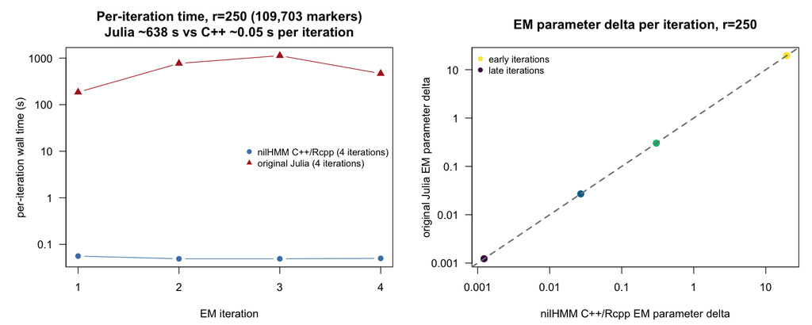

Full panel (109,703 markers/sample), r=250, both cores run to convergence (4 iterations each). Left: per-iteration wall time (original Julia ~638 s/iteration vs nilHMM C++/Rcpp ~0.05 s/iteration). Right: each iteration’s EM parameter-convergence delta (max |Delta(alpha,beta)|, RTIGER’s convergence criterion, not a log-likelihood change), C++ against original Julia on a log-log 1:1 line, early (yellow) to late (purple).

## 3. Throughput, scaling with markers

Shared-panel head-to-head on the five thinned sizes (6,857 -> 13,713 -> 27,426 -> 54,852 -> 109,703), all measured for both cores. The **figure** plots *per-iteration* wall time, whose log-log slope is the empirical complexity exponent: at r=250 the original is markers^1.69, the C++/Rcpp core markers^0.98 (linear). The **table** reports *full-fit* wall time to convergence and the resulting speed-up.

```r
sc <- fread(f("rtiger_marker_scaling_r250.csv"))
w <- dcast(sc, mps ~ core, value.var = "total")[order(-mps)]
w[, speedup := round(orig / cpp)]
knitr::kable(
  w[, .(
    `markers/sample` = mps, `C++/Rcpp (s)` = round(cpp, 3),
    `orig Julia (s)` = round(orig), `speed-up` = speedup
  )],
  caption = "Full-fit wall time to convergence at r=250 (3 samples, eps=0.01), all five sizes measured; the speed-up grows with problem size because the C++ core is near-linear."
)
```

Full-fit wall time to convergence at r=250 (3 samples, eps=0.01), all five sizes measured; the speed-up grows with problem size because the C++ core is near-linear.

| markers/sample | C++/Rcpp (s) | orig Julia (s) | speed-up |
| --- | --- | --- | --- |
| 109703 | 0.205 | 2551 | 12444 |
| 54852 | 0.078 | 948 | 12150 |
| 27426 | 0.053 | 305 | 5756 |
| 13713 | 0.020 | 74 | 3680 |
| 6857 | 0.010 | 20 | 1973 |

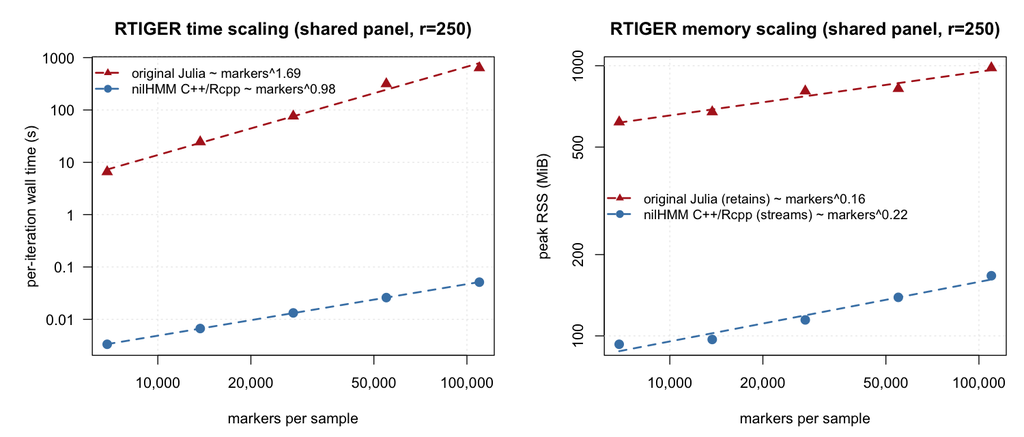

RTIGER scaling on the shared panel at r=250, original array-retaining Julia vs nilHMM C++/Rcpp. Points are measurements at all five sizes (both cores); dashed lines the power-law fits. Left: per-iteration wall time (original ~markers^1.69, C++/Rcpp ~markers^0.98 linear). Right: peak resident memory on cleanly thinned inputs; the C++ core streams sufficient statistics and stays ~6-7x lower.

## 4. Memory

The C++ E-step folds each chain into fixed-size pooled sufficient statistics (the s x s transition counts, the start counts, and a map of gamma-weighted counts over the distinct (k, n) read-count pairs) and discards each chain’s per-position zeta/gamma/alpha/beta arrays immediately. Peak scratch is therefore one chain’s worth, O(T_max s^2), independent of the sample count N, whereas the array-retaining original holds all chains at once, O(N T s^2). Because the rigidity is collapsed, the C++ memory is also essentially independent of r.

```r
cm <- fread(f("rtiger_memory_markers_r250.csv"))
jm <- fread(f("rtiger_julia_memory_markers_r250.csv"))
setnames(cm, "peak_rss_mib", "C++/Rcpp (MiB)")
setnames(jm, "peak_rss_mib", "orig Julia (MiB)")
mm <- merge(cm, jm, by = "markers", all = TRUE)[order(-markers)]
mm[, ratio := round(`orig Julia (MiB)` / `C++/Rcpp (MiB)`, 1)]
knitr::kable(mm,
  col.names = c("markers/sample", "C++/Rcpp (MiB)", "orig Julia (MiB)", "ratio"),
  caption = "Peak resident memory at r=250 (3 samples), C++ vs original Julia, all five sizes measured on cleanly thinned inputs (each process loads only its own marker set). Both scale with marker count (per-chain arrays are O(T)); the ~6-7x separation is the original's per-chain array retention, and it widens further on the sample axis."
)
```

Peak resident memory at r=250 (3 samples), C++ vs original Julia, all five sizes measured on cleanly thinned inputs (each process loads only its own marker set). Both scale with marker count (per-chain arrays are O(T)); the ~6-7x separation is the original’s per-chain array retention, and it widens further on the sample axis.

| markers/sample | C++/Rcpp (MiB) | orig Julia (MiB) | ratio |
| --- | --- | --- | --- |
| 109703 | 167.0 | 982.3 | 5.9 |
| 54852 | 138.9 | 823.1 | 5.9 |
| 27426 | 114.6 | 806.1 | 7.0 |
| 13713 | 97.0 | 674.8 | 7.0 |
| 6857 | 93.1 | 619.1 | 6.6 |

On cleanly thinned inputs both cores scale with marker count (the per-chain arrays are O(T)); the ~6-7x separation is the original’s per-chain array retention. The asymptotically meaningful axis is the sample count N, on which the streamed C++ scratch does not grow while the original’s does.

## 5. Reproducing

`scripts/bench_rtiger_r250.R` builds the shared panel from the staged Col x Ler inputs, runs the C++ core at each size (to convergence + delta trace), compares against the original-Julia oracle at all five sizes, and writes the CSVs. `scripts/rtiger_julia_conv_worker.jl <orig_base> <level> 250` produces the original runs; `scripts/rtiger_r250_plot.R` writes the figures. Only the built nilHMM C++ core and (for the small original sizes) Julia are needed.